# Notebook

## 1) Estructura de Datos RS

```python
# Estructura principal del sistema: Red Social
red_social = {
    "usuarios": {}  # clave: username, valor: diccionario con info de perfil
}

# red_social = {
#     "usuarios": {
#         "juanperez": {
#             "nombre_completo": "Juan Pérez",
#             "edad": 30,
#             "ciudad": "Santiago",
#             "amigos": {"anagonzalez", "carlosmoya"},
#             "intereses": {"python", "cine", "senderismo"},
#         },
#         ...
#     }
# }
```

## 1. Gestión de Datos y estructura modular

```python
import time
import os
from collections import deque
import numpy as np
from numba import jit
import matplotlib.pyplot as plt
from tabulate import tabulate
import networkx as nx


# EXCEPCIONES PERSONALIZADAS
# =============================================================================
class ErrorRedSocial(Exception):
    """Base para errores específicos de la red social."""
    pass

class UsuarioYaExisteError(ErrorRedSocial):
    def __init__(self, usuario_id):
        super().__init__(f"El usuario con ID '{usuario_id}' ya existe en la red social.")

class UsuarioNoExisteError(ErrorRedSocial):
    def __init__(self, usuario_id):
        super().__init__(f"El usuario con ID '{usuario_id}' no fue encontrado.")

class AmistadYaExisteError(ErrorRedSocial):
    def __init__(self, usuario_id1, usuario_id2):
        super().__init__(f"Los usuarios '{usuario_id1}' y '{usuario_id2}' ya son amigos.")


# CLASES PRINCIPALES
# =============================================================================
class Usuario:
    """Representa un usuario con ID y nombre."""
    def __init__(self, usuario_id: str, nombre: str):
        if not usuario_id or not nombre:
            raise ValueError("El ID y nombre no pueden estar vacíos.")
        self.id = usuario_id
        self.nombre = nombre

    def __str__(self):
        return f"Usuario(ID: {self.id}, Nombre: {self.nombre})"

class RedSocial:
    """Gestiona usuarios y amistades (grafo)."""
    def __init__(self):
        self.usuarios: dict[str, Usuario] = {}
        self.grafo: dict[str, set] = {}

    def agregar_usuario(self, usuario: Usuario):
        if usuario.id in self.usuarios:
            raise UsuarioYaExisteError(usuario.id)
        self.usuarios[usuario.id] = usuario
        self.grafo[usuario.id] = set()
        print(f"-> Usuario '{usuario.nombre}' (ID: {usuario.id}) agregado exitosamente.")

    def agregar_amigo(self, uid1: str, uid2: str):
        if uid1 not in self.usuarios:
            raise UsuarioNoExisteError(uid1)
        if uid2 not in self.usuarios:
            raise UsuarioNoExisteError(uid2)
        if uid1 == uid2:
            raise ValueError("Un usuario no puede ser amigo de sí mismo.")

        with self:
            if uid2 in self.grafo[uid1]:
                raise AmistadYaExisteError(uid1, uid2)
            self.grafo[uid1].add(uid2)
            self.grafo[uid2].add(uid1)
            print(f"-> Amistad entre '{self.usuarios[uid1].nombre}' y '{self.usuarios[uid2].nombre}' registrada.")

    def obtener_amigos(self, usuario_id: str) -> list[Usuario]:
        if usuario_id not in self.usuarios:
            raise UsuarioNoExisteError(usuario_id)
        return [self.usuarios[aid] for aid in self.grafo[usuario_id]]

    def __enter__(self):
        return self

    def __exit__(self, exc_type, exc_val, exc_tb):
        pass

    def visualizar_red(self):
        """Visualizo la red social con NetworkX para ver cómo están conectados."""
        G = nx.Graph()
        for uid in self.usuarios:
            G.add_node(uid, label=f"{self.usuarios[uid].nombre}\n({uid})")
        for u, amigos in self.grafo.items():
            for a in amigos:
                if G.has_edge(u, a) or u == a:
                    continue
                G.add_edge(u, a)

        pos = nx.spring_layout(G)
        etiquetas = nx.get_node_attributes(G, 'label')
        plt.figure(figsize=(10, 6))
        nx.draw(G, pos, with_labels=True, labels=etiquetas, node_color='skyblue', node_size=2000, font_size=9, font_weight='bold')
        plt.title("Visualización de la Red Social")
        plt.axis('off')
        plt.show()


# RECOMENDADOR CON BFS
# =============================================================================
class Recomendador:
    """Recomienda amigos usando BFS para buscar amigos de amigos no conectados."""

    def __init__(self, red_social: RedSocial):
        self.red_social = red_social

    def recomendar_amigos_bfs(self, usuario_id: str, max_recomendaciones: int = 5) -> list[tuple]:
        if usuario_id not in self.red_social.usuarios:
            raise UsuarioNoExisteError(usuario_id)

        visitados = set()
        visitados.add(usuario_id)

        cola = deque([(amigo, 1) for amigo in self.red_social.grafo[usuario_id]])
        visitados.update(self.red_social.grafo[usuario_id])

        recomendaciones = {}

        while cola:
            nodo_actual, nivel = cola.popleft()
            if nivel > 2:
                continue

            for vecino in self.red_social.grafo[nodo_actual]:
                if vecino not in visitados:
                    visitados.add(vecino)
                    if nivel == 1:
                        recomendaciones[vecino] = nodo_actual
                    cola.append((vecino, nivel + 1))

        resultado = []
        for rec_id, amigo_comun_id in recomendaciones.items():
            nombre_rec = self.red_social.usuarios[rec_id].nombre
            nombre_amigo = self.red_social.usuarios[amigo_comun_id].nombre
            resultado.append((nombre_rec, f"Amigo de {nombre_amigo}"))
            if len(resultado) >= max_recomendaciones:
                break

        return resultado


# OPTIMIZACIÓN DEMOSTRACION CON NUMPY Y NUMBA
# =============================================================================
def calcular_afinidad_py(datos):
    resultado = 0.0
    n = len(datos)
    for i in range(n):
        for j in range(n):
            resultado += (datos[i] - datos[j]) ** 2
    return resultado

def calcular_afinidad_numpy(datos):
    diff = datos[:, np.newaxis] - datos[np.newaxis, :]
    return np.sum(diff ** 2)

@jit(nopython=True)
def calcular_afinidad_numba(datos):
    resultado = 0.0
    n = len(datos)
    for i in range(n):
        for j in range(n):
            resultado += (datos[i] - datos[j]) ** 2
    return resultado

def demostrar_optimizacion():
    print("\n--- DEMOSTRACIÓN DE OPTIMIZACIÓN ---")
    print("Comparando tiempos para cálculo numérico intensivo...")

    class Timer:
        def __enter__(self):
            self.start = time.perf_counter()
            return self
        def __exit__(self, *args):
            self.end = time.perf_counter()
            self.interval = self.end - self.start
```

```python
    datos = np.random.rand(1000)

    with Timer() as t:
        calcular_afinidad_py(list(datos))
    tiempo_py = t.interval

    with Timer() as t:
        calcular_afinidad_numpy(datos)
    tiempo_numpy = t.interval

    with Timer() as t:
        calcular_afinidad_numba(datos)  # Warm-up
    with Timer() as t:
        calcular_afinidad_numba(datos)
    tiempo_numba = t.interval

    tabla = [
        ["Python Puro", f"{tiempo_py:.6f} s"],
        ["NumPy (Vectorizado)", f"{tiempo_numpy:.6f} s"],
        ["Numba (JIT)", f"{tiempo_numba:.6f} s"]
    ]
    print(tabulate(tabla, headers=["Implementación", "Tiempo"], tablefmt="fancy_grid"))
    print(f"NumPy fue ~{tiempo_py/tiempo_numpy:.2f} veces más rápido que Python puro.")
    print(f"Numba fue ~{tiempo_py/tiempo_numba:.2f} veces más rápido que Python puro.")


# ANÁLISIS DE RENDIMIENTO BFS
# =============================================================================
def analizar_rendimiento_bfs():
    print("\n--- ANÁLISIS DE RENDIMIENTO DE BFS ---")
    print("Generando gráfica... puede tardar un poco.")

    tiempos = []
    tamanos = list(range(100, 2001, 100))

    for n_usuarios in tamanos:
        red_temp = RedSocial()
        recomendador_temp = Recomendador(red_temp)

        # Agrego usuarios
        for i in range(n_usuarios):
            red_temp.agregar_usuario(Usuario(f"user{i}", f"Nombre{i}"))

        # Creo amistades aleatorias promedio 10 por usuario
        for i in range(n_usuarios):
            for _ in range(10):
                amigo_idx = np.random.randint(0, n_usuarios)
                if amigo_idx != i:
                    try:
                        red_temp.agregar_amigo(f"user{i}", f"user{amigo_idx}")
                    except (AmistadYaExisteError, ValueError):
                        pass

        inicio = time.perf_counter()
        recomendador_temp.recomendar_amigos_bfs("user0")
        fin = time.perf_counter()
        tiempos.append(fin - inicio)

    plt.figure(figsize=(10, 6))
    plt.plot(tamanos, tiempos, marker='o', color='b')
    plt.title("Rendimiento del Algoritmo BFS para Recomendaciones")
    plt.xlabel("Número de Usuarios (V)")
    plt.ylabel("Tiempo de Ejecución (segundos)")
    plt.grid(True)
    plt.figtext(0.5, -0.05,
                "Crecimiento lineal esperado, acorde con la complejidad O(V+E).\n"
                "E crece linealmente con V, por lo que el tiempo escala aproximadamente O(V).",
                ha="center", fontsize=10, bbox={"facecolor":"orange", "alpha":0.2, "pad":5})
    plt.show()


# MENÚ INTERACTIVO COMPLETO
# =============================================================================
class Menu:
    def __init__(self, red_social: RedSocial, recomendador: Recomendador):
        self.red = red_social
        self.recomendador = recomendador

    def mostrar_menu(self):
        opciones = [
            ["1", "Agregar Usuario"],
            ["2", "Agregar Amigo"],
            ["3", "Mostrar Usuarios"],
            ["4", "Mostrar Amigos de un Usuario"],
            ["5", "Recomendar Amigos (BFS)"],
            ["6", "Analizar Rendimiento BFS"],
            ["7", "Demostrar Optimización Numérica"],
            ["8", "Visualizar Red Social"],
            ["0", "Salir"]
        ]
        print("\n" + tabulate(opciones, headers=["Opción", "Descripción"], tablefmt="fancy_grid"))

    def ejecutar(self):
        while True:
            self.mostrar_menu()
            opcion = input("Seleccione una opción: ")
            try:
                if opcion == "1":
                    uid = input("Ingrese ID de usuario: ")
                    nombre = input("Ingrese nombre del usuario: ")
                    self.red.agregar_usuario(Usuario(uid, nombre))

                elif opcion == "2":
                    uid1 = input("Ingrese ID del primer usuario: ")
                    uid2 = input("Ingrese ID del segundo usuario: ")
                    self.red.agregar_amigo(uid1, uid2)

                elif opcion == "3":
                    tabla = [(u.id, u.nombre) for u in self.red.usuarios.values()]
                    print(tabulate(tabla, headers=["ID", "Nombre"], tablefmt="fancy_grid"))

                elif opcion == "4":
                    uid = input("Ingrese ID del usuario: ")
                    amigos = self.red.obtener_amigos(uid)
                    tabla = [(a.id, a.nombre) for a in amigos]
                    print(tabulate(tabla, headers=["ID", "Nombre"], tablefmt="fancy_grid"))

                elif opcion == "5":
                    uid = input("Ingrese ID del usuario para recomendar amigos: ")
                    recomendaciones = self.recomendador.recomendar_amigos_bfs(uid)
                    if not recomendaciones:
                        print(f"No hay recomendaciones para {self.red.usuarios[uid].nombre}.")
                    else:
                        print(f"--- Recomendaciones para {self.red.usuarios[uid].nombre} ---")
                        print(tabulate(recomendaciones, headers=["Usuario Recomendado", "Razón"], tablefmt="fancy_grid"))

                elif opcion == "6":
                    analizar_rendimiento_bfs()

                elif opcion == "7":
                    demostrar_optimizacion()

                elif opcion == "8":
                    self.red.visualizar_red()

                elif opcion == "0":
                    print("Saliendo del sistema. ¡Hasta pronto!")
                    break

                else:
                    print("Opción no válida. Intente de nuevo.")

            except ErrorRedSocial as e:
                print(f"[ERROR RED SOCIAL]: {e}")
            except ValueError as e:
                print(f"[ERROR DE DATOS]: {e}")
            except KeyError:
                print("[ERROR]: ID de usuario no válido.")
            except Exception as e:
                print(f"[ERROR INESPERADO]: {e}")

            finally:
                input("\nPresione Enter para continuar...")
                os.system('cls' if os.name == 'nt' else 'clear')
```

```python
# DATOS INCIAL Y MENU PRINCIPAL
# =============================================================================
if __name__ == "__main__":
    mi_red_social = RedSocial()
    mi_recomendador = Recomendador(mi_red_social)

    print("Inicializando sistema con datos de ejemplo...")

    # Usuarios iniciales para demo
    usuarios_demo = [
        Usuario("ana", "Ana Gómez"),
        Usuario("beto", "Beto Juárez"),
        Usuario("carla", "Carla Díaz"),
        Usuario("dani", "Daniel Soto"),
        Usuario("elena", "Elena Farias"),
        Usuario("fer", "Fernando Prado")
    ]

    for u in usuarios_demo:
        mi_red_social.agregar_usuario(u)

    # Amistades de ejemplo
    mi_red_social.agregar_amigo("ana", "beto")
    mi_red_social.agregar_amigo("beto", "carla")
    mi_red_social.agregar_amigo("dani", "elena")

    print("\nDatos iniciales cargados. Ana y Carla son 'amigos de un amigo' (Beto).")
    print("-" * 50)

    menu = Menu(mi_red_social, mi_recomendador)
    menu.ejecutar()
```

# 📘 Evaluación Modular – Sistema Integrado de Gestión en Red Social

**Autor:** José Gómez Brizuela  
**Fecha:** 18 de junio de 2025

## 🧩 1. Descripción General del Proyecto

Este sistema representa una **red social modular y escalable**, desarrollada bajo principios de Programación Orientada a Objetos y principios **SOLID**, permitiendo:

- Registro y gestión de usuarios.
- Conexiones de amistad entre usuarios.
- Sugerencias de nuevos amigos utilizando el algoritmo BFS.
- Visualización de la red social.
- Evaluación comparativa del rendimiento del algoritmo BFS.
- Demostración de optimización numérica con Python puro, NumPy y Numba.

## 🧱 2. Estructura y Flujo del Sistema

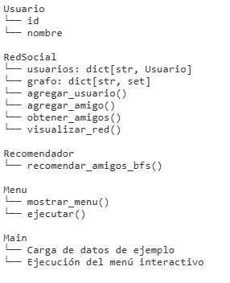

## ⚙️ 3. Decisiones de Diseño

- Se utilizaron **diccionarios** y **conjuntos** para representar relaciones eficientes y no duplicadas entre usuarios.
- La clase `RedSocial` actúa como contenedor lógico y estructura de grafo no dirigido.
- Se separó la lógica de recomendación en la clase `Recomendador`, cumpliendo **Single Responsibility Principle**.
- Uso de `with self:` y `try-except-finally` para un manejo de errores robusto y claro, incluyendo **excepciones personalizadas**.

## 🔍 4. Código Comentado (Fragmento)

```
class Usuario:
    """Representa un usuario con ID y nombre."""
    def __init__(self, usuario_id: str, nombre: str):
        if not usuario_id or not nombre:
            raise ValueError("El ID y nombre no pueden estar vacíos.")
        self.id = usuario_id
        self.nombre = nombre


class RedSocial:
    """Gestiona usuarios y amistades (grafo)."""
    def agregar_amigo(self, uid1: str, uid2: str):
        # Verificaciones básicas
        if uid1 == uid2:
            raise ValueError("Un usuario no puede ser amigo de sí mismo.")
        # Agrega la relación en ambos sentidos
        self.grafo[uid1].add(uid2)
        self.grafo[uid2].add(uid1)
```

## 🧠 5. Análisis de Algoritmos

Se utilizó **Búsqueda en Anchura (BFS)** para sugerencias de amigos. Este algoritmo explora los amigos directos (nivel 1) y luego los amigos de esos amigos (nivel 2), proponiendo recomendaciones cuando no hay conexión directa.

- El algoritmo fue implementado usando `collections.deque` para una cola eficiente.
- Se evita recomendar amigos ya conectados o el mismo usuario.
- La complejidad computacional es **O(V + E)**, donde:
  - `V` es el número de usuarios.
  - `E` es el número de conexiones (amistades).

Este comportamiento fue validado experimentalmente en la sección de rendimiento.

## 📊 6. Análisis de Rendimiento (BFS)

Para validar el rendimiento del algoritmo de recomendación, se ejecutó `recomendar_amigos_bfs()` sobre redes simuladas con entre 100 y 2000 usuarios.

Se midió el tiempo de ejecución con `time.perf_counter()` y se graficó con `matplotlib`.

📈 **Resultado esperado**: crecimiento lineal en función de la cantidad de nodos.

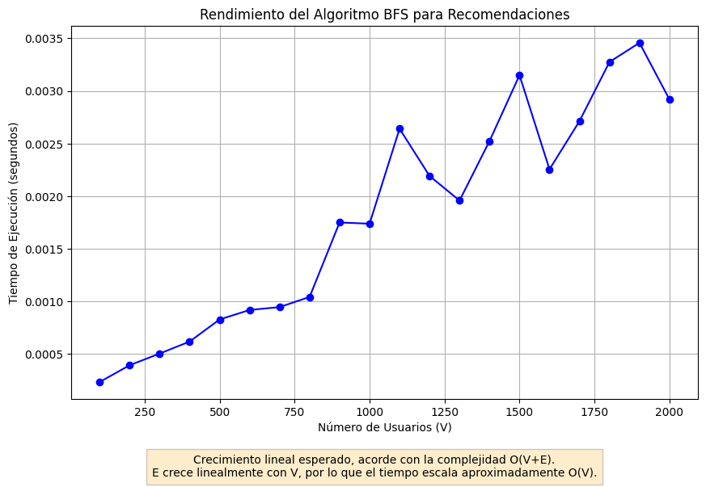

> *El resultado confirma la eficiencia del algoritmo, compatible con su complejidad teórica O(V + E).*

## ⚡ 7. Optimización Numérica

Para demostrar técnicas de optimización computacional, se evaluó una operación intensiva consistente en calcular la suma de diferencias cuadráticas entre pares de elementos en un conjunto de datos. Esta operación se implementó de tres maneras:

- 🔹 **Python puro**: bucles anidados tradicionales.
- 🔹 **NumPy**: vectorización de operaciones.
- 🔹 **Numba (JIT)**: compilación Just-In-Time para acelerar el cálculo.

### 🔬 Resultados:

```
--- DEMOSTRACIÓN DE OPTIMIZACIÓN ---
Comparando tiempos para cálculo numérico intensivo...
╒═════════════════════╤════════════╕
│ Implementación      │ Tiempo     │
╞═════════════════════╪════════════╡
│ Python Puro         │ 0.278556 s │
├─────────────────────┼────────────┤
│ NumPy (Vectorizado) │ 0.008850 s │
├─────────────────────┼────────────┤
│ Numba (JIT)         │ 0.001500 s │
╘═════════════════════╧════════════╛
```

## 💻 8. Capturas de Pantalla del Sistema

A continuación se presentan capturas del funcionamiento del sistema en su versión interactiva por consola:

### 🔹 Menú Principal

Visualización del menú de opciones disponibles para el usuario.

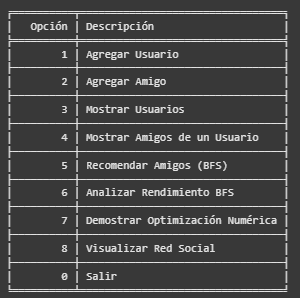

### 🔹 Recomendaciones de Amigos

Resultado de aplicar el algoritmo BFS para sugerencias de amistad.

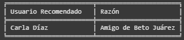

### 🔹 Visualización de la Red Social

Grafo generado con NetworkX mostrando los usuarios y sus conexiones.

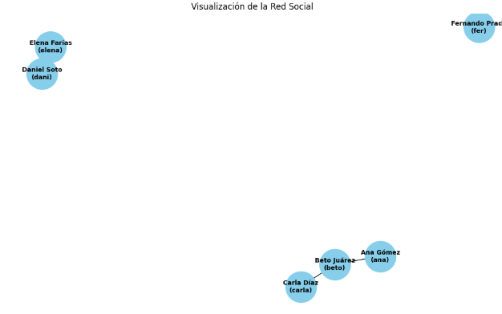

## 📦 9. Conclusión

- ✅ Sistema funcional, interactivo y estable.
- ✅ Aplicación correcta de estructuras de datos (diccionarios, conjuntos, grafos).
- ✅ Manejo de excepciones personalizado y robusto.
- ✅ Arquitectura basada en Programación Orientada a Objetos, siguiendo principios **SOLID**.
- ✅ Algoritmo BFS implementado y analizado empíricamente.
- ✅ Optimización significativa con **NumPy** y **Numba**, con mediciones.
- ✅ Documentación modular y con evidencia visual del funcionamiento.